# Education

# 1 Description of DataSchema variable

- Short name: `education`
- Variable label: `Highest level of formal education achieved`
- Domain: `Socio-demographic and economic characteristics`
- Value type: `categorical`
- Category coding:

| **Code** | **Category Label** |
| --- | --- |
| 0 | less than primary education |
| 1 | primary education |
| 2 | secondary education |
| 3 | tertiary education |

- Category missings:

| **Code** | **Category Label** |
| --- | --- |
| 991 | CAPI/interviewer error |
| 992 | Impute |
| 993 | Disable to measure |
| 994 | Not attempt/not done |
| 995 | Does not answer |
| 996 | Not applicable |
| 997 | Refuse |
| 998 | Do not know |
| 999 | Missing |

# 2 Data process

## 2.1 Enland

### 2.1.1 Wave 1

#### 2.1.1.1 Study-specific variable description

- Name: `edqual`
- Label: `educational qualification - info merged from current and previous waves`
- Categories:
  - `1 = NVQ4/NVQ5/Degree or equiv`
  - `2 = Higher ed below degree`
  - `3 = NVQ3/GCE A Level equiv`
  - `4 = NVQ2/GCE O Level equiv`
  - `5 = NVQ1/CSE other grade equiv`
  - `6 = Foreign/other`
  - `7 = No qualification`
- Missings:
  - `-9 = refusal`
  - `-8 = don't know`
  - `-2 = not asked`
  - `-1 = not applicable`
- Description:

EDQUAL

| Sample size | Missing values |
| --- | --- |
| 12099 | 35 |

Category

|  | 1 | 2 | 3 | 4 | 5 | 6 | 7 |
| --- | --- | --- | --- | --- | --- | --- | --- |
| Frequency | 1388.00 | 1333.00 | 764.00 | 1974.00 | 582.00 | 1015.00 | 5008.00 |
| Percentage | 11.47 | 11.02 | 6.31 | 16.32 | 4.81 | 8.39 | 41.39 |

Type of missing

|  | -9 | -8 | -2 | -1 | NA |
| --- | --- | --- | --- | --- | --- |
| Frequency | 6.00 | 11.00 | 0 | 18.00 | 0 |
| Percentage | 0.05 | 0.09 | 0 | 0.15 | 0 |

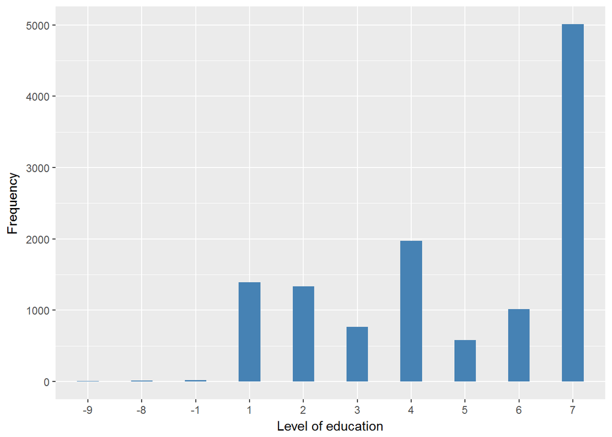

#### 2.1.1.2 Harmonisation algorithm

To compute the harmonized variable from the study-specific variable has to be recoded as follows:

- `1 "NVQ4/NVQ5/Degree or equiv" into 3`
- `keep "Higher ed below degree" into 2`
- `3 "NVQ3/GCE A Level equiv" into 2`
- `4 "NVQ2/GCE O Level equiv" into 2`
- `5 "NVQ1/CSE other grade equiv" into 2`
- `6 "Foreign/other" into 999`
- `7 "No qualification" into 0`
- `-9 "refusal" into 997`
- `-8 "don't know" into 998`
- `-2 "not asked" into 995`
- `-1 "not applicable" into 996`
- `NA into 999`

**R script:**

```r
ELSA_ds_w1 <- tibble(id = ELSA_w1_educ$id)
ELSA_ds_w1$education <- car::recode(ELSA_w1_educ$edqual, "1=3; 3=2; 4=2; 5=2; 6=999; 7=0; -9=997; -8=998;-2=995; -1=996;  NA=999")
ELSA_ds_w1$education <- labelled(ELSA_ds_w1$education, labels = c(`less than primary education` = 0,
    `primary education` = 1, `secondary education` = 2, `tertiary education` = 3,
    Missing = 999, `Do not know` = 998, Refuse = 997, `Not attempt not done` = 994,
    `Does not answer` = 995, `Not applicable` = 996, `Disable to measure` = 993,
    Impute = 992, `CAPI interviewer error` = 991))
label(ELSA_ds_w1$education) <- ds_label
```

#### 2.1.1.3 Statistical description of the new harmonised variable

| Sample size | Missing values |
| --- | --- |
| 12099 | 1050 |

Category

|  | 0 | 2 | 3 |
| --- | --- | --- | --- |
| Frequency | 5008.00 | 4653.00 | 1388.00 |
| Percentage | 41.39 | 38.46 | 11.47 |

Type of missing

|  | 991 | 992 | 993 | 994 | 995 | 996 | 997 | 998 | 999 | NA |
| --- | --- | --- | --- | --- | --- | --- | --- | --- | --- | --- |
| Frequency | 0 | 0 | 0 | 0 | 0 | 18.00 | 6.00 | 11.00 | 1015.00 | 0 |
| Percentage | 0 | 0 | 0 | 0 | 0 | 0.15 | 0.05 | 0.09 | 8.39 | 0 |

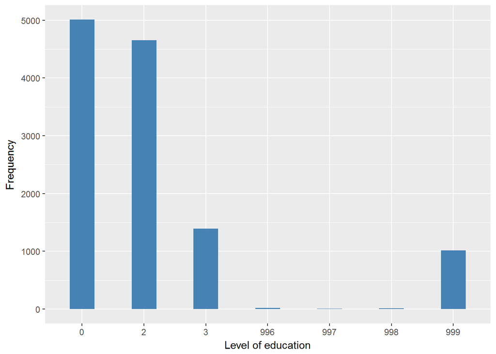

#### 2.1.1.4 Validation

|  | 7->0 | (2,3,4,5)->2 | 1->3 | -1->996 | -9->997 | -8->998 | 6->999 |
| --- | --- | --- | --- | --- | --- | --- | --- |
| BeforeH | 5008 | 4653 | 1388 | 18 | 6 | 11 | 1015 |
| AfterH | 5008 | 4653 | 1388 | 18 | 6 | 11 | 1015 |

### 2.1.2 Wave 2

#### 2.1.2.1 Study-specific variable description

- Name: `edqual`
- Label: `educational qualification - info merged from current and previous waves`
- Categories:
  - `1 = NVQ4/NVQ5/Degree or equiv`
  - `2 = Higher ed below degree`
  - `3 = NVQ3/GCE A Level equiv`
  - `4 = NVQ2/GCE O Level equiv`
  - `5 = NVQ1/CSE other grade equiv`
  - `6 = Foreign/other`
  - `7 = No qualification`
- Missings:
  - `-9 = refusal`
  - `-8 = don't know`
  - `-2 = not asked`
  - `-1 = not applicable`
- Description:

EDQUAL

| Sample size | Missing values |
| --- | --- |
| 9432 | 46 |

Category

|  | 1 | 2 | 3 | 4 | 5 | 6 | 7 |
| --- | --- | --- | --- | --- | --- | --- | --- |
| Frequency | 1168.00 | 1118.00 | 643.00 | 1622.0 | 436.00 | 789.00 | 3610.00 |
| Percentage | 12.38 | 11.85 | 6.82 | 17.2 | 4.62 | 8.37 | 38.27 |

Type of missing

|  | -9 | -8 | -2 | -1 | NA |
| --- | --- | --- | --- | --- | --- |
| Frequency | 1.00 | 6.00 | 34.00 | 5.00 | 0 |
| Percentage | 0.01 | 0.06 | 0.36 | 0.05 | 0 |

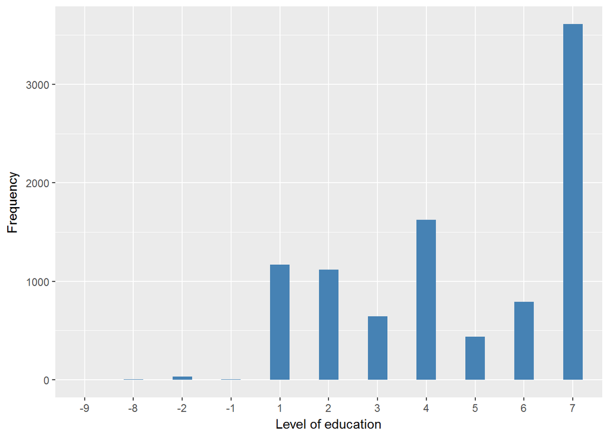

#### 2.1.2.2 Harmonisation algorithm

To compute the harmonized variable from the study-specific variable has to be recoded as follows:

- `1 "NVQ4/NVQ5/Degree or equiv" into 3`
- `keep "Higher ed below degree" into 2`
- `3 "NVQ3/GCE A Level equiv" into 2`
- `4 "NVQ2/GCE O Level equiv" into 2`
- `5 "NVQ1/CSE other grade equiv" into 2`
- `6 "Foreign/other" into 999`
- `7 "No qualification" into 0`
- `-9 "refusal" into 997`
- `-8 "don't know" into 998`
- `-2 "not asked" into 995`
- `-1 "not applicable" into 996`
- `NA into 999`

**R script:**

```r
ELSA_ds_w2 <- tibble(id = ELSA_w2_educ$id)
ELSA_ds_w2$education <- car::recode(ELSA_w2_educ$edqual, "1=3; 3=2; 4=2; 5=2; 6=999; 7=0; -9=997; -8=998;-2=995; -1=996;  NA=999")
ELSA_ds_w2$education <- labelled(ELSA_ds_w2$education, labels = c(`less than primary education` = 0,
    `primary education` = 1, `secondary education` = 2, `tertiary education` = 3,
    Missing = 999, `Do not know` = 998, Refuse = 997, `Not attempt not done` = 994,
    `Does not answer` = 995, `Not applicable` = 996, `Disable to measure` = 993,
    Impute = 992, `CAPI interviewer error` = 991))
label(ELSA_ds_w2$education) <- ds_label
```

#### 2.1.2.3 Statistical description of the new harmonised variable

| Sample size | Missing values |
| --- | --- |
| 9432 | 835 |

Category

|  | 0 | 2 | 3 |
| --- | --- | --- | --- |
| Frequency | 3610.00 | 3819.00 | 1168.00 |
| Percentage | 38.27 | 40.49 | 12.38 |

Type of missing

|  | 991 | 992 | 993 | 994 | 995 | 996 | 997 | 998 | 999 | NA |
| --- | --- | --- | --- | --- | --- | --- | --- | --- | --- | --- |
| Frequency | 0 | 0 | 0 | 0 | 34.00 | 5.00 | 1.00 | 6.00 | 789.00 | 0 |
| Percentage | 0 | 0 | 0 | 0 | 0.36 | 0.05 | 0.01 | 0.06 | 8.37 | 0 |

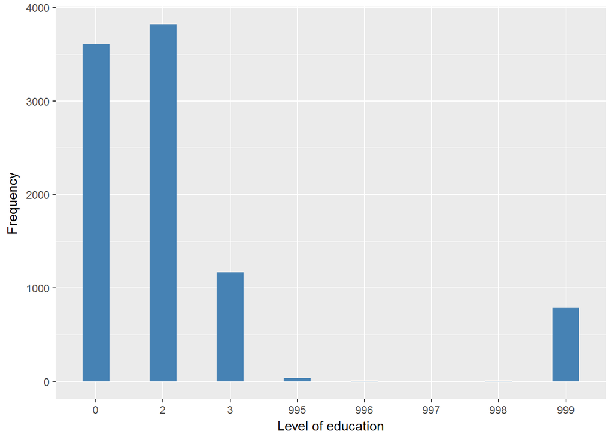

#### 2.1.2.4 Validation

|  | 7->0 | (2,3,4,5)->2 | 1->3 | -2->995 | -1->996 | -9->997 | -8->998 | 6->999 |
| --- | --- | --- | --- | --- | --- | --- | --- | --- |
| BeforeH | 3610 | 3819 | 1168 | 34 | 5 | 1 | 6 | 789 |
| AfterH | 3610 | 3819 | 1168 | 34 | 5 | 1 | 6 | 789 |

### 2.1.3 Wave 3

#### 2.1.3.1 Study-specific variable description

- Name: `edqual`
- Label: `educational qualification - info merged from current and previous waves`
- Categories:
  - `1 = NVQ4/NVQ5/Degree or equiv`
  - `2 = Higher ed below degree`
  - `3 = NVQ3/GCE A Level equiv`
  - `4 = NVQ2/GCE O Level equiv`
  - `5 = NVQ1/CSE other grade equiv`
  - `6 = Foreign/other`
  - `7 = No qualification`
- Missings:
  - `-9 = refusal`
  - `-8 = don't know`
  - `-2 = not asked`
  - `-1 = not applicable`
- Description:

EDQUAL

| Sample size | Missing values |
| --- | --- |
| 9771 | 53 |

Category

|  | 1 | 2 | 3 | 4 | 5 | 6 | 7 |
| --- | --- | --- | --- | --- | --- | --- | --- |
| Frequency | 1666.00 | 1406.00 | 764.00 | 1799.00 | 456.00 | 729.00 | 2898.00 |
| Percentage | 17.05 | 14.39 | 7.82 | 18.41 | 4.67 | 7.46 | 29.66 |

Type of missing

|  | -9 | -8 | -2 | -1 | NA |
| --- | --- | --- | --- | --- | --- |
| Frequency | 2.00 | 5.00 | 46.00 | 0 | 0 |
| Percentage | 0.02 | 0.05 | 0.47 | 0 | 0 |

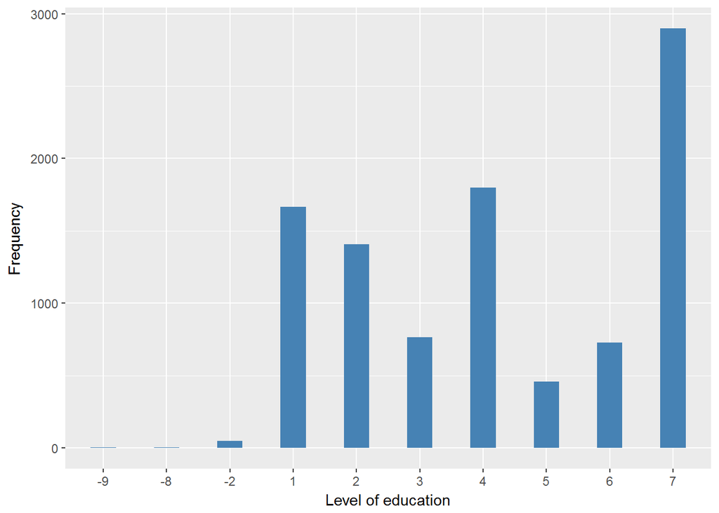

#### 2.1.3.2 Harmonisation algorithm

To compute the harmonized variable from the study-specific variable has to be recoded as follows:

- `1 "NVQ4/NVQ5/Degree or equiv" into 3`
- `keep "Higher ed below degree" into 2`
- `3 "NVQ3/GCE A Level equiv" into 2`
- `4 "NVQ2/GCE O Level equiv" into 2`
- `5 "NVQ1/CSE other grade equiv" into 2`
- `6 "Foreign/other" into 999`
- `7 "No qualification" into 0`
- `-9 "refusal" into 997`
- `-8 "don't know" into 998`
- `-2 "not asked" into 995`
- `-1 "not applicable" into 996`
- `NA into 999`

**R script:**

```r
ELSA_ds_w3 <- tibble(id = ELSA_w3_educ$id)
ELSA_ds_w3$education <- car::recode(ELSA_w3_educ$edqual, "1=3; 3=2; 4=2; 5=2; 6=999; 7=0; -9=997; -8=998;-2=995; -1=996;  NA=999")
ELSA_ds_w3$education <- labelled(ELSA_ds_w3$education, labels = c(`less than primary education` = 0,
    `primary education` = 1, `secondary education` = 2, `tertiary education` = 3,
    Missing = 999, `Do not know` = 998, Refuse = 997, `Not attempt not done` = 994,
    `Does not answer` = 995, `Not applicable` = 996, `Disable to measure` = 993,
    Impute = 992, `CAPI interviewer error` = 991))
label(ELSA_ds_w3$education) <- ds_label
```

#### 2.1.3.3 Statistical description of the new harmonised variable

| Sample size | Missing values |
| --- | --- |
| 9771 | 782 |

Category

|  | 0 | 2 | 3 |
| --- | --- | --- | --- |
| Frequency | 2898.00 | 4425.00 | 1666.00 |
| Percentage | 29.66 | 45.29 | 17.05 |

Type of missing

|  | 991 | 992 | 993 | 994 | 995 | 996 | 997 | 998 | 999 | NA |
| --- | --- | --- | --- | --- | --- | --- | --- | --- | --- | --- |
| Frequency | 0 | 0 | 0 | 0 | 46.00 | 0 | 2.00 | 5.00 | 729.00 | 0 |
| Percentage | 0 | 0 | 0 | 0 | 0.47 | 0 | 0.02 | 0.05 | 7.46 | 0 |

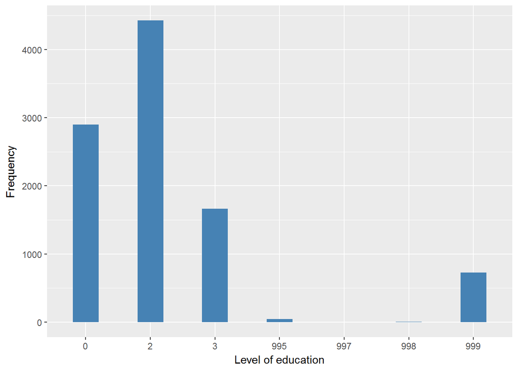

#### 2.1.3.4 Validation

|  | 7->0 | (2,3,4,5)->2 | 1->3 | -2->995 | -9->997 | -8->998 | 6->999 |
| --- | --- | --- | --- | --- | --- | --- | --- |
| BeforeH | 2898 | 4425 | 1666 | 46 | 2 | 5 | 729 |
| AfterH | 2898 | 4425 | 1666 | 46 | 2 | 5 | 729 |

### 2.1.4 Wave 4

#### 2.1.4.1 Study-specific variable description

- Name: `edqual`
- Label: `educational qualification - info merged from current and previous waves`
- Categories:
  - `1 = NVQ4/NVQ5/Degree or equiv`
  - `2 = Higher ed below degree`
  - `3 = NVQ3/GCE A Level equiv`
  - `4 = NVQ2/GCE O Level equiv`
  - `5 = NVQ1/CSE other grade equiv`
  - `6 = Foreign/other`
  - `7 = No qualification`
- Missings:
  - `-9 = refusal`
  - `-8 = don't know`
  - `-2 = not asked`
  - `-1 = not applicable`
- Description:

EDQUAL

| Sample size | Missing values |
| --- | --- |
| 11050 | 104 |

Category

|  | 1 | 2 | 3 | 4 | 5 | 6 | 7 |
| --- | --- | --- | --- | --- | --- | --- | --- |
| Frequency | 1860.00 | 1528.00 | 860.00 | 2048.00 | 479.00 | 1015.00 | 3156.00 |
| Percentage | 16.83 | 13.83 | 7.78 | 18.53 | 4.33 | 9.19 | 28.56 |

Type of missing

|  | -9 | -8 | -2 | -1 | NA |
| --- | --- | --- | --- | --- | --- |
| Frequency | 49.00 | 11.0 | 44.0 | 0 | 0 |
| Percentage | 0.44 | 0.1 | 0.4 | 0 | 0 |

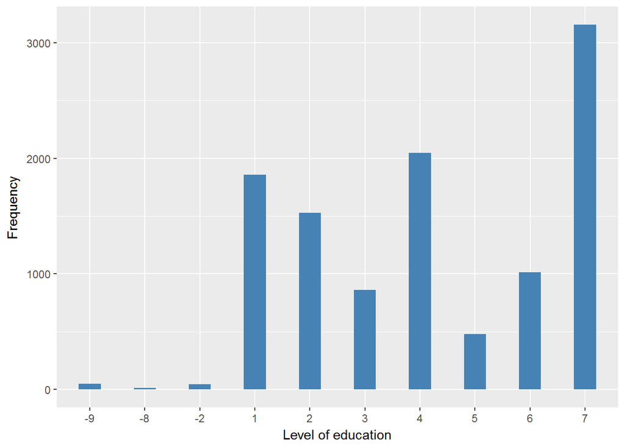

#### 2.1.4.2 Harmonisation algorithm

To compute the harmonized variable from the study-specific variable has to be recoded as follows:

- `1 "NVQ4/NVQ5/Degree or equiv" into 3`
- `keep "Higher ed below degree" into 2`
- `3 "NVQ3/GCE A Level equiv" into 2`
- `4 "NVQ2/GCE O Level equiv" into 2`
- `5 "NVQ1/CSE other grade equiv" into 2`
- `6 "Foreign/other" into 999`
- `7 "No qualification" into 0`
- `-9 "refusal" into 997`
- `-8 "don't know" into 998`
- `-2 "not asked" into 995`
- `-1 "not applicable" into 996`
- `NA into 999`

**R script:**

```r
ELSA_ds_w4 <- tibble(id = ELSA_w4_educ$id)
ELSA_ds_w4$education <- car::recode(ELSA_w4_educ$edqual, "1=3; 3=2; 4=2; 5=2; 6=999; 7=0; -9=997; -8=998;-2=995; -1=996;  NA=999")
ELSA_ds_w4$education <- labelled(ELSA_ds_w4$education, labels = c(`less than primary education` = 0,
    `primary education` = 1, `secondary education` = 2, `tertiary education` = 3,
    Missing = 999, `Do not know` = 998, Refuse = 997, `Not attempt not done` = 994,
    `Does not answer` = 995, `Not applicable` = 996, `Disable to measure` = 993,
    Impute = 992, `CAPI interviewer error` = 991))
label(ELSA_ds_w4$education) <- ds_label
```

#### 2.1.4.3 Statistical description of the new harmonised variable

| Sample size | Missing values |
| --- | --- |
| 11050 | 1119 |

Category

|  | 0 | 2 | 3 |
| --- | --- | --- | --- |
| Frequency | 3156.00 | 4915.00 | 1860.00 |
| Percentage | 28.56 | 44.48 | 16.83 |

Type of missing

|  | 991 | 992 | 993 | 994 | 995 | 996 | 997 | 998 | 999 | NA |
| --- | --- | --- | --- | --- | --- | --- | --- | --- | --- | --- |
| Frequency | 0 | 0 | 0 | 0 | 44.0 | 0 | 49.00 | 11.0 | 1015.00 | 0 |
| Percentage | 0 | 0 | 0 | 0 | 0.4 | 0 | 0.44 | 0.1 | 9.19 | 0 |

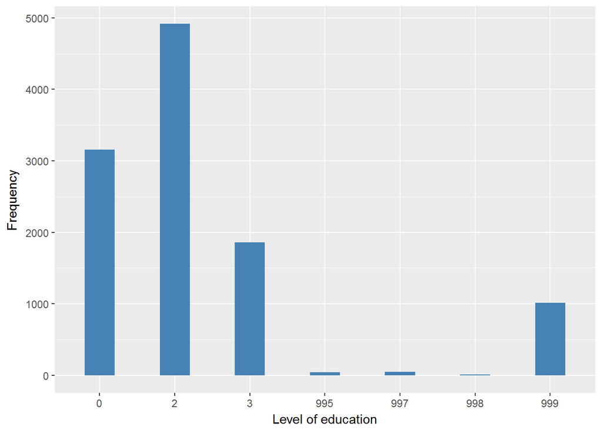

#### 2.1.4.4 Validation

|  | 7->0 | (2,3,4,5)->2 | 1->3 | -2->995 | -9->997 | -8->998 | 6->999 |
| --- | --- | --- | --- | --- | --- | --- | --- |
| BeforeH | 3156 | 4915 | 1860 | 44 | 49 | 11 | 1015 |
| AfterH | 3156 | 4915 | 1860 | 44 | 49 | 11 | 1015 |

### 2.1.5 Wave 5

#### 2.1.5.1 Study-specific variable description

- Name: `edqual`
- Label: `educational qualification - info merged from current and previous waves`
- Categories:
  - `1 = NVQ4/NVQ5/Degree or equiv`
  - `2 = Higher ed below degree`
  - `3 = NVQ3/GCE A Level equiv`
  - `4 = NVQ2/GCE O Level equiv`
  - `5 = NVQ1/CSE other grade equiv`
  - `6 = Foreign/other`
  - `7 = No qualification`
- Missings:
  - `-9 = refusal`
  - `-8 = don't know`
  - `-2 = not asked`
  - `-1 = not applicable`
- Description:

EDQUAL

| Sample size | Missing values |
| --- | --- |
| 10274 | 164 |

Category

|  | 1 | 2 | 3 | 4 | 5 | 6 | 7 |
| --- | --- | --- | --- | --- | --- | --- | --- |
| Frequency | 1708.00 | 1380.00 | 792.00 | 1873.00 | 429.00 | 1112.00 | 2816.00 |
| Percentage | 16.62 | 13.43 | 7.71 | 18.23 | 4.18 | 10.82 | 27.41 |

Type of missing

|  | -9 | -8 | -2 | -1 | NA |
| --- | --- | --- | --- | --- | --- |
| Frequency | 30.00 | 62.0 | 72.0 | 0 | 0 |
| Percentage | 0.29 | 0.6 | 0.7 | 0 | 0 |

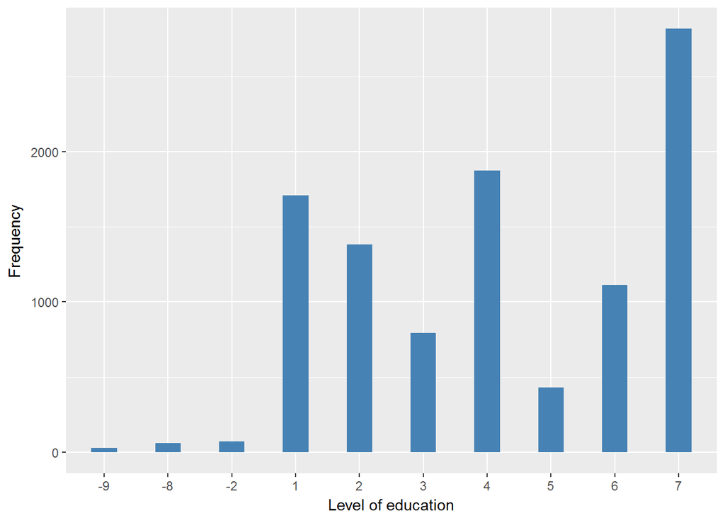

#### 2.1.5.2 Harmonisation algorithm

To compute the harmonized variable from the study-specific variable has to be recoded as follows:

- `1 "NVQ4/NVQ5/Degree or equiv" into 3`
- `keep "Higher ed below degree" into 2`
- `3 "NVQ3/GCE A Level equiv" into 2`
- `4 "NVQ2/GCE O Level equiv" into 2`
- `5 "NVQ1/CSE other grade equiv" into 2`
- `6 "Foreign/other" into 999`
- `7 "No qualification" into 0`
- `-9 "refusal" into 997`
- `-8 "don't know" into 998`
- `-2 "not asked" into 995`
- `-1 "not applicable" into 996`
- `NA into 999`

**R script:**

```r
ELSA_ds_w5 <- tibble(id = ELSA_w5_educ$id)
ELSA_ds_w5$education <- car::recode(ELSA_w5_educ$edqual, "1=3; 3=2; 4=2; 5=2; 6=999; 7=0; -9=997; -8=998;-2=995; -1=996;  NA=999")
ELSA_ds_w5$education <- labelled(ELSA_ds_w5$education, labels = c(`less than primary education` = 0,
    `primary education` = 1, `secondary education` = 2, `tertiary education` = 3,
    Missing = 999, `Do not know` = 998, Refuse = 997, `Not attempt not done` = 994,
    `Does not answer` = 995, `Not applicable` = 996, `Disable to measure` = 993,
    Impute = 992, `CAPI interviewer error` = 991))
label(ELSA_ds_w5$education) <- ds_label
```

#### 2.1.5.3 Statistical description of the new harmonised variable

| Sample size | Missing values |
| --- | --- |
| 10274 | 1276 |

Category

|  | 0 | 2 | 3 |
| --- | --- | --- | --- |
| Frequency | 2816.00 | 4474.00 | 1708.00 |
| Percentage | 27.41 | 43.55 | 16.62 |

Type of missing

|  | 991 | 992 | 993 | 994 | 995 | 996 | 997 | 998 | 999 | NA |
| --- | --- | --- | --- | --- | --- | --- | --- | --- | --- | --- |
| Frequency | 0 | 0 | 0 | 0 | 72.0 | 0 | 30.00 | 62.0 | 1112.00 | 0 |
| Percentage | 0 | 0 | 0 | 0 | 0.7 | 0 | 0.29 | 0.6 | 10.82 | 0 |

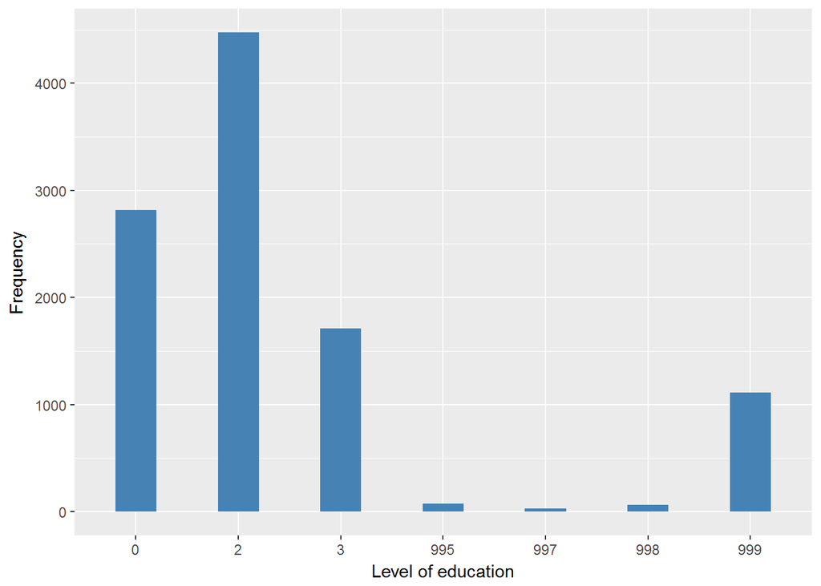

#### 2.1.5.4 Validation

|  | 7->0 | (2,3,4,5)->2 | 1->3 | -2->995 | -9->997 | -8->998 | 6->999 |
| --- | --- | --- | --- | --- | --- | --- | --- |
| BeforeH | 2816 | 4474 | 1708 | 72 | 30 | 62 | 1112 |
| AfterH | 2816 | 4474 | 1708 | 72 | 30 | 62 | 1112 |

### 2.1.6 Wave 6

#### 2.1.6.1 Study-specific variable description

- Name: `edqual`
- Label: `educational qualification - info merged from current and previous waves`
- Categories:
  - `1 = NVQ4/NVQ5/Degree or equiv`
  - `2 = Higher ed below degree`
  - `3 = NVQ3/GCE A Level equiv`
  - `4 = NVQ2/GCE O Level equiv`
  - `5 = NVQ1/CSE other grade equiv`
  - `6 = Foreign/other`
  - `7 = No qualification`
- Missings:
  - `-9 = refusal`
  - `-8 = don't know`
  - `-2 = not asked`
  - `-1 = not applicable`
- Description:

EDQUAL

| Sample size | Missing values |
| --- | --- |
| 10601 | 154 |

Category

|  | 1 | 2 | 3 | 4 | 5 | 6 | 7 |
| --- | --- | --- | --- | --- | --- | --- | --- |
| Frequency | 1858.00 | 1422.00 | 897.00 | 1981.00 | 430.00 | 1204.00 | 2655.00 |
| Percentage | 17.53 | 13.41 | 8.46 | 18.69 | 4.06 | 11.36 | 25.04 |

Type of missing

|  | -9 | -8 | -2 | -1 | NA |
| --- | --- | --- | --- | --- | --- |
| Frequency | 41.00 | 51.00 | 62.00 | 0 | 0 |
| Percentage | 0.39 | 0.48 | 0.58 | 0 | 0 |

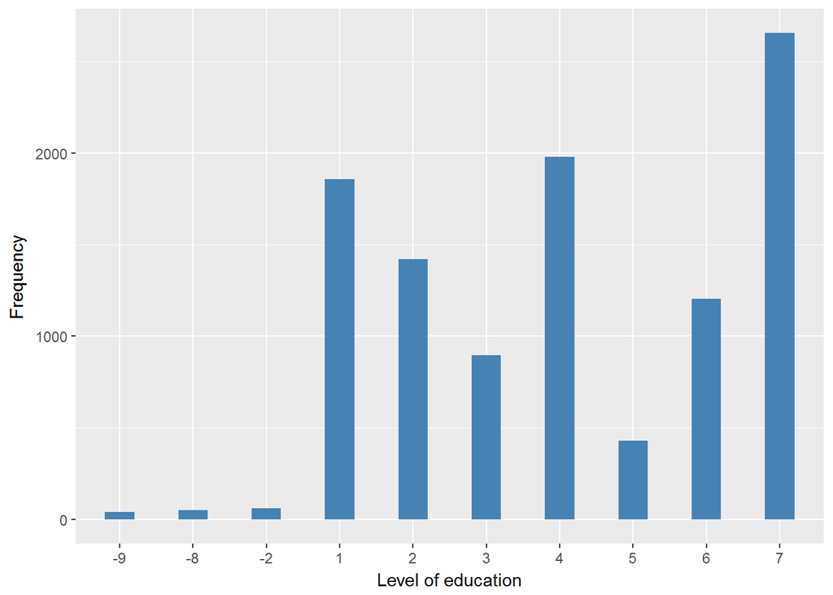

#### 2.1.6.2 Harmonisation algorithm

To compute the harmonized variable from the study-specific variable has to be recoded as follows:

- `1 "NVQ4/NVQ5/Degree or equiv" into 3`
- `keep "Higher ed below degree" into 2`
- `3 "NVQ3/GCE A Level equiv" into 2`
- `4 "NVQ2/GCE O Level equiv" into 2`
- `5 "NVQ1/CSE other grade equiv" into 2`
- `6 "Foreign/other" into 999`
- `7 "No qualification" into 0`
- `-9 "refusal" into 997`
- `-8 "don't know" into 998`
- `-2 "not asked" into 995`
- `-1 "not applicable" into 996`
- `NA into 999`

**R script:**

```r
ELSA_ds_w6 <- tibble(id = ELSA_w6_educ$id)
ELSA_ds_w6$education <- car::recode(ELSA_w6_educ$edqual, "1=3; 3=2; 4=2; 5=2; 6=999; 7=0; -9=997; -8=998;-2=995; -1=996;  NA=999")
ELSA_ds_w6$education <- labelled(ELSA_ds_w6$education, labels = c(`less than primary education` = 0,
    `primary education` = 1, `secondary education` = 2, `tertiary education` = 3,
    Missing = 999, `Do not know` = 998, Refuse = 997, `Not attempt not done` = 994,
    `Does not answer` = 995, `Not applicable` = 996, `Disable to measure` = 993,
    Impute = 992, `CAPI interviewer error` = 991))
label(ELSA_ds_w6$education) <- ds_label
```

#### 2.1.6.3 Statistical description of the new harmonised variable

| Sample size | Missing values |
| --- | --- |
| 10601 | 1358 |

Category

|  | 0 | 2 | 3 |
| --- | --- | --- | --- |
| Frequency | 2655.00 | 4730.00 | 1858.00 |
| Percentage | 25.04 | 44.62 | 17.53 |

Type of missing

|  | 991 | 992 | 993 | 994 | 995 | 996 | 997 | 998 | 999 | NA |
| --- | --- | --- | --- | --- | --- | --- | --- | --- | --- | --- |
| Frequency | 0 | 0 | 0 | 0 | 62.00 | 0 | 41.00 | 51.00 | 1204.00 | 0 |
| Percentage | 0 | 0 | 0 | 0 | 0.58 | 0 | 0.39 | 0.48 | 11.36 | 0 |

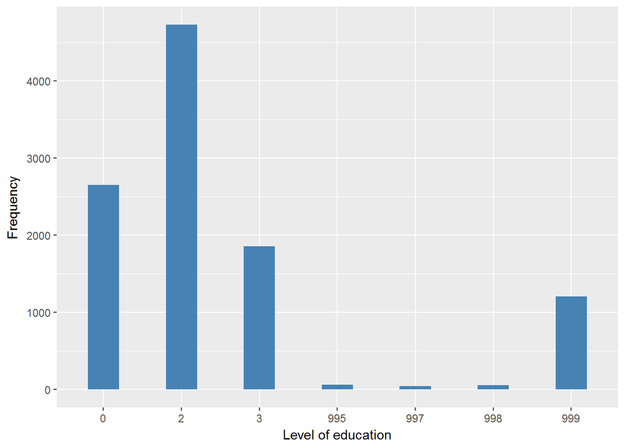

#### 2.1.6.4 Validation

|  | 7->0 | (2,3,4,5)->2 | 1->3 | -2->995 | -9->997 | -8->998 | 6->999 |
| --- | --- | --- | --- | --- | --- | --- | --- |
| BeforeH | 2655 | 4730 | 1858 | 62 | 41 | 51 | 1204 |
| AfterH | 2655 | 4730 | 1858 | 62 | 41 | 51 | 1204 |

### 2.1.7 Wave 7

#### 2.1.7.1 Study-specific variable description

| **Name** | `edqual` |
| --- | --- |
| **Label** | `educational qualification - info merged from current and previous waves` |
| **Table name** | `wave7_dv` |
| **Categories** | `1 = NVQ4/NVQ5/Degree or equiv` `2 = Higher ed below degree` `3 = NVQ3/GCE A Level equiv` `4 = NVQ2/GCE O Level equiv` `5 = NVQ1/CSE other grade equiv` `6 = Foreign/other` `7 = No qualification` |
| **Missings** | `-9 = refusal` `-8 = don't know` `-2 = not asked` `-1 = not applicable` |
| **Description** |  |

edqual

| Sample size | Missing values |
| --- | --- |
| 9666 | 322 |

Category

|  | 1 | 2 | 3 | 4 | 5 | 6 | 7 |
| --- | --- | --- | --- | --- | --- | --- | --- |
| Frequency | 1628.00 | 1258.00 | 829.00 | 1838.00 | 375.00 | 1184.00 | 2232.00 |
| Percentage | 16.84 | 13.01 | 8.58 | 19.02 | 3.88 | 12.25 | 23.09 |

Type of missing

|  | -9 | -8 | -2 | -1 | NA |
| --- | --- | --- | --- | --- | --- |
| Frequency | 31.00 | 46.00 | 245.00 | 0 | 0 |
| Percentage | 0.32 | 0.48 | 2.53 | 0 | 0 |

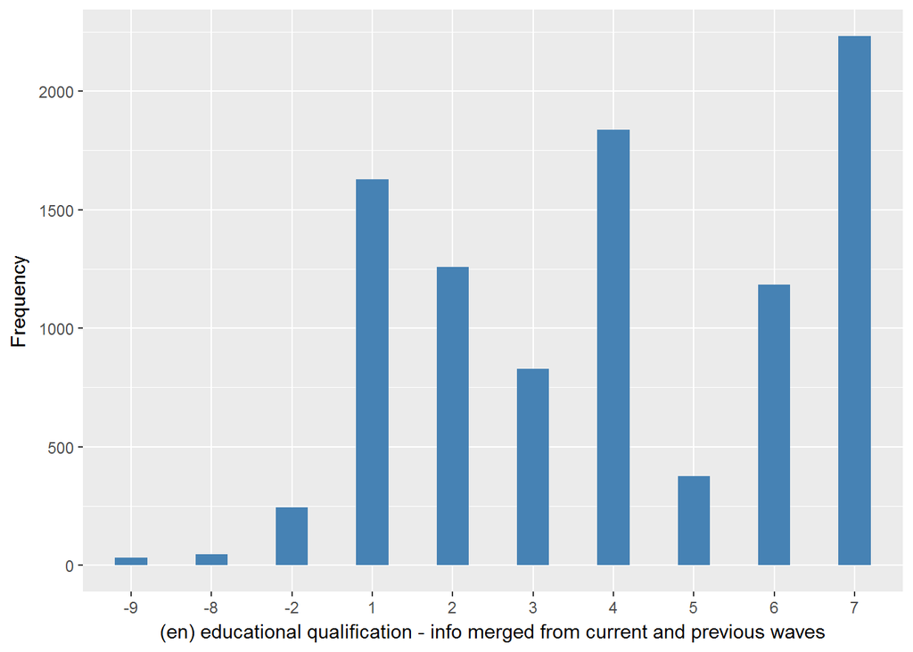

#### 2.1.7.2 Harmonisation algorithm

To compute the harmonized variable from the study-specific variable has to be recoded as follows:

- `1 "NVQ4/NVQ5/Degree or equiv" into 3`
- `keep "Higher ed below degree" into 2`
- `3 "NVQ3/GCE A Level equiv" into 2`
- `4 "NVQ2/GCE O Level equiv" into 2`
- `5 "NVQ1/CSE other grade equiv" into 2`
- `6 "Foreign/other" into 999`
- `7 "No qualification" into 0`
- `-9 "refusal" into 997`
- `-8 "don't know" into 998`
- `-2 "not asked" into 995`
- `-1 "not applicable" into 996`
- `NA into 999`

**R script:**

```r
ELSA_ds_w7 <- tibble(id = ELSA_w7$id)
ELSA_ds_w7$education <- car::recode(ELSA_w7$edqual, "1=3; 3=2; 4=2; 5=2; 6=999; 7=0; -9=997; -8=998;-2=995; -1=996;  NA=999")
ELSA_ds_w7$education <- labelled(ELSA_ds_w7$education, labels = c(`less than primary education` = 0,
    `primary education` = 1, `secondary education` = 2, `tertiary education` = 3,
    Missing = 999, `Do not know` = 998, Refuse = 997, `Not attempt not done` = 994,
    `Does not answer` = 995, `Not applicable` = 996, `Disable to measure` = 993,
    Impute = 992, `CAPI interviewer error` = 991))
label(ELSA_ds_w7$education) <- ds_label
```

#### 2.1.7.3 Statistical description of the new harmonised variable

| Sample size | Missing values |
| --- | --- |
| 9666 | 1506 |

Category

|  | 0 | 2 | 3 |
| --- | --- | --- | --- |
| Frequency | 2232.00 | 4300.00 | 1628.00 |
| Percentage | 23.09 | 44.49 | 16.84 |

Type of missing

|  | 991 | 992 | 993 | 994 | 995 | 996 | 997 | 998 | 999 | NA |
| --- | --- | --- | --- | --- | --- | --- | --- | --- | --- | --- |
| Frequency | 0 | 0 | 0 | 0 | 245.00 | 0 | 31.00 | 46.00 | 1184.00 | 0 |
| Percentage | 0 | 0 | 0 | 0 | 2.53 | 0 | 0.32 | 0.48 | 12.25 | 0 |

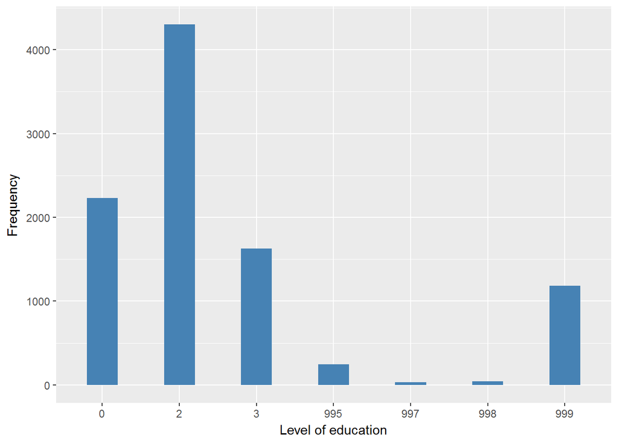

#### 2.1.7.4 Validation

|  | 7->0 | (2,3,4,5)->2 | 1->3 | -2->995 | -9->997 | -8->998 | 6->999 |
| --- | --- | --- | --- | --- | --- | --- | --- |
| BeforeH | 2232 | 4300 | 1628 | 245 | 31 | 46 | 1184 |
| AfterH | 2232 | 4300 | 1628 | 245 | 31 | 46 | 1184 |

# 3 Quality estimation

No comments